# R Demos Miscellania

## Random helpful `tidyverse` packages

## `tibble`

### it’s just a better data.frame

- [Docs](https://tibble.tidyverse.org/)
- Re-imagined `data.frame` with a better print method and better string/factor handling
  - `tidyverse` packages will output `tibble`s instead of `data.frame`s
- Also includes the [tribble](https://tibble.tidyverse.org/reference/tribble.html) function which is handy for manual table creation:

```r
tribble(
  ~x,    ~y,
  "foo", "bar",
)
```

```
## # A tibble: 1 × 2
##   x     y
##   <chr> <chr>
## 1 foo   bar
```

## `stringr`

### do things with strings

- [Docs](https://stringr.tidyverse.org/) and [cheatsheet](https://github.com/rstudio/cheatsheets/blob/master/strings.pdf)
- More consistent string manipulation interface
  - All functions start with `str_`
  - Match, substitute, split, concatenate etc. with regular expressions
  - What is a regex? [Quick intro](https://cran.r-project.org/web/packages/stringr/vignettes/regular-expressions.html)

## `glue`

### don’t use `paste` ever again

- [Docs](https://glue.tidyverse.org/)
- special syntax for string interpolation (a.k.a. template strings or f-strings in other languages)

```r
x <- 3
glue("The value of x is {x}")
```

```
## The value of x is 3
```

- `glue` is vectorized

```r
glue("{1:10} is {if_else(1:10 > 1, 'also ', '')}a cool number")
```

```
## 1 is a cool number
## 2 is also a cool number
## 3 is also a cool number
## 4 is also a cool number
## 5 is also a cool number
## 6 is also a cool number
## 7 is also a cool number
## 8 is also a cool number
## 9 is also a cool number
## 10 is also a cool number
```

## `lubridate`

### the best date library ever

- [Docs](https://lubridate.tidyverse.org/) and [cheatsheet](https://rawgit.com/rstudio/cheatsheets/master/lubridate.pdf)
- Easily parse numbers and strings to date/datetime objects

```r
date1 <- ymd(20200101) # year, month, day
datetime1 <- mdy_hm("April 4, 2012 5:33 pm") # month, day, year, hour, minute
```

- Easily manipulate parts of dates and do date math

```r
month(date1) <- 8 # change the date I just made
last_week <- today() - weeks(1) # subtract a week from a date

# extract events that happened in the last week
the_past_week <- last_week %--% today()
data %<>% filter(date %within% the_past_week)

# group a date column into 10-day intervals
data %<>% mutate(date = floor_date(date, "10 days"))
```

## `haven`

### for all the S***a users out there

- [Docs](https://haven.tidyverse.org/)
- `read_dta` function to read `.dta` files
  - Can also read SAS and SPSS data files
- `as_factor` to convert Stata factors, also has its own class for dealing with labelled data
  - more on labelling etc. [here](https://haven.tidyverse.org/articles/semantics.html)

## `readxl`

### you can also read Excel files

- [Docs](https://readxl.tidyverse.org/)
  - Not much to say on this, it reads Excel using the `read_xlsx` function

## `forcats`

### it’s an anagram of “factors”

- Tries to provide more consistent factor handling
- [Docs](https://forcats.tidyverse.org/) and [cheatsheet](https://github.com/rstudio/cheatsheets/raw/main/factors.pdf)
- Factors are still a personal pain point in using R
  - It’s been **a bit** easier since I started using this library

## `purrr`

[figure not shown]

## For hardcore (and not so hardcore) functional programmers

- [Docs](https://purrr.tidyverse.org/) and [cheatsheet](https://github.com/rstudio/cheatsheets/blob/master/purrr.pdf)
- Introduces “lambda” syntax for more easily creating functions
- Introduces `map_*` family of functions to replace `lapply`, `sapply`, et al.
- Assorted other functions to make your code sleek and functional
- Standard cite for functional programming in R is Advanced R [chapters 9–11](https://adv-r.hadley.nz/fp.html)

## Lambdas

### interesting (ab)use of R formulas

- R formulas are unevaluated, just one aspect of the language’s non-standard evaluation
- Someone smart realized that formulas can be used as a shorthand for functions
  - `rlang`’s [`as_function`](https://rlang.r-lib.org/reference/as_function.html) converts a one-sided formula to function

```r
f <- rlang::as_function(~ .x + 2) # same as f <- function (x) x + 2
f(3)
```

```
## [1] 5
```

## Lambdas

### usage in `tidyverse`

- You can use `.x` and `.y` to refer to the first two arguments, `..1`, `..2`, `..3`, etc. if you have more than two arguments
- Throughout the documentation for `tidyverse` you will see that you can use `purrr`-style lambdas anywhere you could use a function

## Map family

- Another primary usage for lambdas is in the `map_` family of functions in `purrr`
- Pass in your data (as a list, vector, data.frame, etc.) and a function to apply to each element of your data
  - `purrr` will return a list by default, but there is a function, e.g. `map_chr`, to return a character vector
  - There are also variants for the number of input arguments
- Example:

```r
data <- tibble(flavor = c("Chocolate", "Vanilla"), topping = c("almonds", "strawberries"))
data %>% mutate(
  description = map2_chr(flavor, topping, ~paste(.x, "ice cream with", .y, "on top"))
)
```

```
## # A tibble: 2 × 3
##   flavor    topping      description
##   <chr>     <chr>        <chr>
## 1 Chocolate almonds      Chocolate ice cream with almonds on top
## 2 Vanilla   strawberries Vanilla ice cream with strawberries on top
```

```r
# Just an example... glue("{flavor} ice cream with {topping} on top") is preferred.
```

- Using `map_*` may seem superfluous in a vectorized language, but it is necessary in situations where your functions are not properly vectorized!

-Here is how Advanced R (section 9.4) organizes the map family: by number of arguments (rows), and by return type (columns)

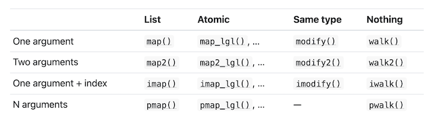

## Other assorted stuff in `purrr`

- [Other list operations](https://purrr.tidyverse.org/reference/index.html#section-other-vector-transforms) such as `reduce`, `accumulate`, and `flatten`
- Do things with [predicate functionals](https://purrr.tidyverse.org/reference/index.html#section-predicate-functionals)
- Modify function behavior using higher-order adverbs
  - Example:

```r
# instead of THROWING an error, return a list that contains the error object itself
safely_sqrt <- safely(sqrt)
safely_sqrt("cheese")
```

```
## $result
## NULL
##
## $error
## <simpleError in .Primitive("sqrt")(x): non-numeric argument to mathematical function>
```

## More `magrittr`

## References

- [Docs](https://magrittr.tidyverse.org/)
  - Particularly the usage section
- Get very comfortable with the different usages! They will improve your programming
- I will cover things that I think are interesting, but this documentation is short enough to read in a few minutes

## Argument placeholder

- magrittr uses the dot `.` as a placeholder for the result of the piped-in value
  - This way you can use it in functions where your piped-in value is NOT the first argument
  - `x %>% f(y, .)` is equivalent to `f(y, x)`
  - `x %>% f(y, z = .)` is equivalent to `f(y, z = x)`

## Braces

- You can pipe into a set of curly braces for a nice anonymous function syntax, with the dot standing in for the piped-in value:

```r
file_name %>% {
  file.remove(.)
  new_data <- recompile_my_data()
  write_csv(new_data, .)
}
```

## Alternative pipes

- `%<>%` is a pipe that also assigns the resulting expression to the LHS
  - Useful for pipelines which involve a few different steps
- `%$%` is a pipe that exposes the LHS, much like `with` in base R
- Example using both:

```r
data <- tibble(x = rnorm(1000))
data %<>% mutate(y = x^2)
data %$% mean(y)
```

```
## [1] 0.9980293
```

- See [function reference](https://magrittr.tidyverse.org/reference/index.html) for documentation on all the pipes

## Thanks!

- Hopefully these help you get started and give you the confidence to use R in your end-of-semester project
- All the slides are available in the GitHub repository
- I’m mostly here to help with R programming so don’t hesitate to reach out